# Longitudinal G-Formula

## Make a Function

- @param `intervention` Intervention or treatment regime. Options are `NULL`, 0, `rad>0.3`, or `rad>0.1`, as defined above.
- @param `pseudo_cohort_bl` Pseudo-cohort at baseline. We create this object above and have called it `mcdata`.
- @param `endtime` Number of total years for the pseudo-cohort to be followed. In this study, we set `endtime=20`
- @param `mod_e` Pooled linear model for (log) radon exposure while at work. This is model is the annual log-radon exposure (defined above). This model is also created above and stored as the object `mod_e`.
- @param `mod_w` Pooled logistic model for leaving work (at the end of the year) while at work. This models the time-varying confounder of employment. This model is also created above and stored as the object `mod_w`.
- @param `mod_d` Pooled logistic model for death. This models the time-varying outcome of death. This model is also created above and stored as the object `mod_d`.
- @param `seed` Seed value we input so that the results are reproducible.

```r
gformula_risks <- function(intervention=NULL, pseudo_cohort_bl,
                           endtime, mod_e, mod_w, mod_d, seed=NULL){
  N <- nrow(pseudo_cohort_bl)
  ncols <- ncol(pseudo_cohort_bl)
  pseudo_cohort <- slice(pseudo_cohort_bl,rep(1:N, each=endtime))
  pseudo_cohort$gfid <- rep(seq(1, N, 1), each=endtime)
  pseudo_cohort$intime <- rep(seq(0, (endtime-1), 1), times=N)
  pseudo_cohort$outtime <- pseudo_cohort$intime+1
  pseudo_cohort$atwork <- 1
  pseudo_cohort$durwork <- 1
  pseudo_cohort$leavework <- 0
  pseudo_cohort$rad <- 0
  pseudo_cohort$rad_lag1 <- 0
  pseudo_cohort$cum_rad_lag1 <- 0
  pseudo_cohort$durwork_lag1 <- 0
  pseudo_cohort$dead <- 0
  pseudo_cohort$cum_hazard <- 0
  pseudo_cohort$cum_incidence <- 0
  var_e = mean(mod_e$residuals^2)
  set.seed(seed)
  max_e = 7.321276
  for(t in seq(1, endtime, 1)){
    idx = which(pseudo_cohort$outtime == t)
    if(t > 1){
      pseudo_cohort[idx,'cum_rad_lag1'] = pseudo_cohort[idx-1,'cum_rad']
      pseudo_cohort[idx,'rad_lag1'] = pseudo_cohort[idx-1,'rad']
    }
    if(t==1) widx = 1:length(idx)
    if(t > 1){
      widx = which(pseudo_cohort[idx-1,'atwork']==1)
      pseudo_cohort[idx[widx],'leavework'] <- rbinom(n=length(widx), size=1,
                                                     prob=predict(mod_w, newdata = pseudo_cohort[idx[widx],],
                                                                  type = 'response'))
      pseudo_cohort[idx,'atwork'] <- (pseudo_cohort[idx,'leavework']==0 & pseudo_cohort[idx-1,'atwork']==1)
      widx = which(pseudo_cohort[idx,'atwork']==1)
      pseudo_cohort[idx,'durwork'] <- pseudo_cohort[idx-1,'durwork'] + pseudo_cohort[idx,'atwork']
      pseudo_cohort[idx,'durwork_lag1'] <- pseudo_cohort[idx-1,'durwork']
    }
    meanlogr = predict(mod_e, newdata = pseudo_cohort[idx[widx],])
    logr = meanlogr + rnorm(n=length(widx), mean=0, sd=sqrt(var_e))
    pseudo_cohort[idx[widx],'rad'] <- exp(pmin(log(max_e), logr))
    if(typeof(intervention) != "NULL"){
      if(is.numeric(intervention)){
        pseudo_cohort[idx,'rad'] <- intervention
      } else{
        if(is.character(intervention)){
          viol_idx <- with(pseudo_cohort[idx,], which(eval(parse(text=intervention))))
          while(length(viol_idx)>0){
            meanlogr = predict(mod_e, newdata = pseudo_cohort[idx[viol_idx],])
            lograd = meanlogr + rnorm(n=length(viol_idx), mean=0, sd=sqrt(var_e))
            pseudo_cohort[idx[viol_idx],'rad'] <- exp(lograd)
            viol_idx <- with(pseudo_cohort[idx,], which(eval(parse(text=intervention))))
          }}}
    }
    if(t > 1){
      pseudo_cohort[idx,'cum_rad'] = pseudo_cohort[idx-1,'cum_rad'] + pseudo_cohort[idx,'rad']
    } else pseudo_cohort[idx,'cum_rad'] = pseudo_cohort[idx,'rad']
    pseudo_cohort[idx,'dead'] = predict(mod_d, newdata = pseudo_cohort[idx,], type = 'response')
    if(t > 1){
      pseudo_cohort[idx,'cum_incidence'] = pseudo_cohort[idx-1,'cum_incidence'] +
        (1-pseudo_cohort[idx-1,'cum_incidence'])*pseudo_cohort[idx,'dead']
    } else{
      pseudo_cohort[idx,'cum_incidence'] = pseudo_cohort[idx,'dead']
    }
  }
  pseudo_cohort
}
```

## Regime 1: Natural Course (As a Function)

```r
nc = gformula_risks(intervention=NULL,
                    pseudo_cohort_bl=mcdata,
                    endtime=20,
                    mod_e=mod_e, mod_w=mod_w, mod_d=mod_d,
                    seed=12325)
gf_cuminc_nc <- with(nc, tibble(time=seq(0,20, 1),
                                ci=c(0, tapply(cum_incidence,
                                               outtime, mean))))
knitr::kable(gf_cuminc_nc,
             caption = "Cumulative incidence: natural course regime")
```

Cumulative incidence: natural course regime

| time | ci |
| --- | --- |
| 0 | 0.0000000 |
| 1 | 0.1853118 |
| 2 | 0.3523480 |
| 3 | 0.4948295 |
| 4 | 0.6114228 |
| 5 | 0.7044357 |
| 6 | 0.7762090 |
| 7 | 0.8301504 |
| 8 | 0.8700183 |
| 9 | 0.8992587 |
| 10 | 0.9206480 |
| 11 | 0.9363762 |
| 12 | 0.9480581 |
| 13 | 0.9568467 |
| 14 | 0.9635285 |
| 15 | 0.9687199 |
| 16 | 0.9727688 |
| 17 | 0.9759461 |
| 18 | 0.9784746 |
| 19 | 0.9804996 |
| 20 | 0.9821380 |

## Regime 2: No Exposure

```r
unex = gformula_risks(intervention=0,
                      pseudo_cohort_bl=mcdata,
                      endtime=20,
                      mod_e=mod_e, mod_w=mod_w, mod_d=mod_d,
                      seed=12325)
gf_cuminc_unex <- with(unex, tibble(time=seq(0,20, 1),
                                    ci=c(0,
                                         tapply(cum_incidence,
                                                outtime, mean))))
knitr::kable(gf_cuminc_unex,
             caption = "Cumulative incidence: unexposed regime")
```

Cumulative incidence: unexposed regime

| time | ci |
| --- | --- |
| 0 | 0.0000000 |
| 1 | 0.1551826 |
| 2 | 0.2809765 |
| 3 | 0.3833794 |
| 4 | 0.4674376 |
| 5 | 0.5379277 |
| 6 | 0.5965654 |
| 7 | 0.6449063 |
| 8 | 0.6843107 |
| 9 | 0.7160998 |
| 10 | 0.7416395 |
| 11 | 0.7620995 |
| 12 | 0.7785237 |
| 13 | 0.7917648 |
| 14 | 0.8025146 |
| 15 | 0.8113073 |
| 16 | 0.8185484 |
| 17 | 0.8245475 |
| 18 | 0.8295444 |
| 19 | 0.8337274 |
| 20 | 0.8372428 |

## Regime 3: “Slightly below current standard”

0.3 x 1000 pCi/L-year limit

```r
exp3 = gformula_risks(intervention='rad>0.3',
                      pseudo_cohort_bl=mcdata,
                      endtime=20,
                      mod_e=mod_e, mod_w=mod_w, mod_d=mod_d,
                      seed=12325)
gf_cuminc_exp3 <- with(exp3, tibble(time=seq(0,20, 1),
                                    ci=c(0, tapply(cum_incidence,
                                                   outtime, mean))))
knitr::kable(gf_cuminc_exp3,
             caption = "Cumulative incidence: radon>0.3 exposure regime")
```

Cumulative incidence: radon>0.3 exposure regime

| time | ci |
| --- | --- |
| 0 | 0.0000000 |
| 1 | 0.1726130 |
| 2 | 0.3234703 |
| 3 | 0.4517287 |
| 4 | 0.5588723 |
| 5 | 0.6471637 |
| 6 | 0.7181688 |
| 7 | 0.7742639 |
| 8 | 0.8177422 |
| 9 | 0.8512567 |
| 10 | 0.8769662 |
| 11 | 0.8967229 |
| 12 | 0.9120497 |
| 13 | 0.9241015 |
| 14 | 0.9337187 |
| 15 | 0.9414689 |
| 16 | 0.9477903 |
| 17 | 0.9529907 |
| 18 | 0.9572977 |
| 19 | 0.9608905 |
| 20 | 0.9639062 |

## Regime 4: “Well below current standard”

0.1 x 1000 pCi/L-year limit

```r
exp1 = gformula_risks(intervention='rad>0.1',
                      pseudo_cohort_bl=mcdata,
                      endtime=20,
                      mod_e=mod_e, mod_w=mod_w, mod_d=mod_d,
                      seed=12325)
gf_cuminc_exp1 <- with(exp1, tibble(time=seq(0,20, 1),
                                    ci=c(0, tapply(cum_incidence,
                                                   outtime, mean))))
knitr::kable(gf_cuminc_exp1,
             caption = "Cumulative incidence: radon>0.1 exposure regime")
```

Cumulative incidence: radon>0.1 exposure regime

| time | ci |
| --- | --- |
| 0 | 0.0000000 |
| 1 | 0.1637380 |
| 2 | 0.3017197 |
| 3 | 0.4166945 |
| 4 | 0.5132191 |
| 5 | 0.5931417 |
| 6 | 0.6587804 |
| 7 | 0.7119056 |
| 8 | 0.7542917 |
| 9 | 0.7878810 |
| 10 | 0.8144093 |
| 11 | 0.8354030 |
| 12 | 0.8520334 |
| 13 | 0.8653507 |
| 14 | 0.8761327 |
| 15 | 0.8849591 |
| 16 | 0.8922597 |
| 17 | 0.8983618 |
| 18 | 0.9035053 |
| 19 | 0.9078728 |
| 20 | 0.9116041 |

## Visualize the Results

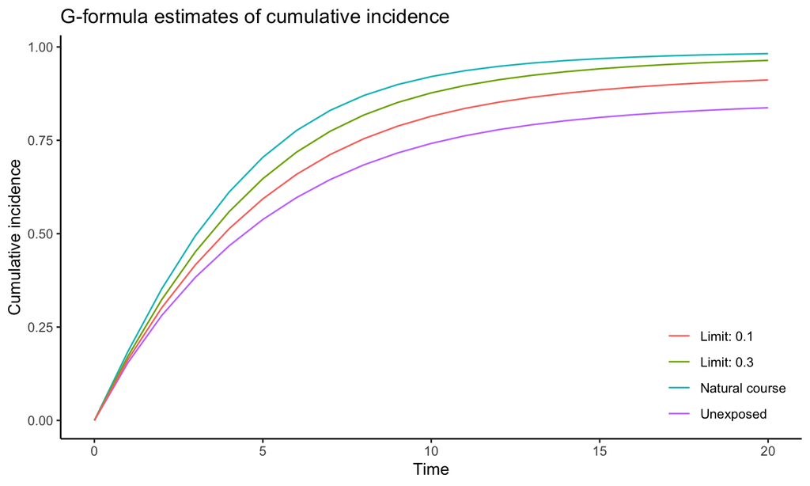

```r
ggplot() +
  geom_line(aes(x=time, y=ci, color="Natural course"), data=gf_cuminc_nc) +
  geom_line(aes(x=time, y=ci, color="Unexposed"), data=gf_cuminc_unex ) +
  geom_line(aes(x=time, y=ci, color="Limit: 0.3"), data=gf_cuminc_exp3 ) +
  geom_line(aes(x=time, y=ci, color="Limit: 0.1"), data=gf_cuminc_exp1 ) +
  scale_y_continuous(name="Cumulative incidence") +
  scale_x_continuous(name="Time", limits=c(0,20)) +
  scale_color_discrete(name="") +
  theme_classic() +
  theme(legend.position = c(0.99,0.01),legend.justification = c(1,0))+
  ggtitle(expression(paste("G-formula estimates of cumulative incidence")))
```

## Bootstrapping

In order to estimate confidence intervals, we will need to get the sample variance using bootstrapping. To do so, we first need to create a function that will perform the bootstrapping. Then we will use the `boot()` function from the `boot` package to perform the bootstrapping \(R\) times, based on that function.

## Bootstrapping

The function `gformula_effectestimates()` takes the following parameters:

- @param `baseline_data` Baseline data set at `intime=0` (created above)
- @param `index` If `NULL`, then original data will be used. If not null, then bootstrapped samples fro the baseline will be taken using the vector `index`. The default is `NULL`.
- @param `fdata` Functional data if `index` is not NULL. The default is the full `miners` data set
- @param `seed` Seed value we input so that the results are reproducible.

```r
# now we turn the g-formula algorithm to get risk difference into a function in order to get bootstrap variance
gformula_effectestimates <- function(data=baseline_data, index=NULL, fdata=miners, endtime=10, seed=NULL){
  # for bootstrap samples, when needed: first take a random sample of the
  #  study IDs, with replacement
  # 0) preprocessing: take bootstrap sample if bootstrapping, otherwise use the observed data
  if(is.null(index)){
    # if index is NULL, then just use original data and do nothing here
  } else{
    # bootstrap sample of the baseline data using the vector 'index'
    data = slice(data, index)
    # resample from the full data according to the id variable in the baseline data
    idindex = tibble(reps = table(data$id), id = as.numeric(names(table(data$id))))
    fdata = merge(idindex, fdata, by='id')
    fdata = slice(fdata, rep(1:dim(fdata)[1], times=fdata$reps))
  }
  # 1) fit models to full data/bootstrap sample of the full data
  mod_e = glm(lograd ~ outtime + cum_rad_lag1 + smoker, data=filter(data, atwork==1))
  # pooled logistic model for leaving work (at the end of the year), while at work
  mod_w = glm(leavework ~ outtime + I(outtime^2) + rad_lag1 + cum_rad_lag1 + smoker,
              data=filter(fdata, atwork==1 | leavework==1), family=binomial(link=logit))
  # pooled logistic model for death
  mod_d = glm(dead ~ outtime + atwork + cum_rad + I(cum_rad*cum_rad) + smoker + smoker*cum_rad,
              data=fdata, family=binomial(link=logit))

  # 2) take large MC sample from baseline data
  mc_iter = 20000
  set.seed(seed)
  mcdata <- slice(data, sample(1:N, size = mc_iter, replace=TRUE))
  # 3) simulate probability distributions in large MC sample using model fits from step 1
  nc = gformula_risks(intervention=NULL,
                      pseudo_cohort_bl=mcdata,
                      endtime=endtime,
                      mod_e=mod_e, mod_w=mod_w, mod_d=mod_d,
                      seed=seed)
  unex = gformula_risks(intervention=0,
                        pseudo_cohort_bl=mcdata,
                        endtime=endtime,
                        mod_e=mod_e, mod_w=mod_w, mod_d=mod_d,
                        seed=seed)
  exp3 = gformula_risks(intervention='rad>0.3',
                        pseudo_cohort_bl=mcdata,
                        endtime=endtime,
                        mod_e=mod_e, mod_w=mod_w, mod_d=mod_d,
                        seed=seed)
  exp1 = gformula_risks(intervention='rad>0.1',
                        pseudo_cohort_bl=mcdata, endtime=endtime,
                        mod_e=mod_e, mod_w=mod_w, mod_d=mod_d,
                        seed=seed)
  # 4) summarize data
  ci_nc = as.numeric(with(nc, tapply(cum_incidence, outtime, mean)))
  ci_unex = as.numeric(with(unex, tapply(cum_incidence, outtime, mean)))
  ci_exp3 = as.numeric(with(exp3, tapply(cum_incidence, outtime, mean)))
  ci_exp1 = as.numeric(with(exp1, tapply(cum_incidence, outtime, mean)))
  # return a vector of risk differences and log-risk ratios at time t=endtime
  # could also calculate for all times
  c(
    rd_exp3_10=c(ci_exp3-ci_nc)[endtime],
    rd_exp1_10=c(ci_exp1-ci_nc)[endtime],
    rd_unex_10=c(ci_unex-ci_nc)[endtime],
    lrr_exp3_10=log(c(ci_exp3/ci_nc)[endtime]),
    lrr_exp1_10=log(c(ci_exp1/ci_nc)[endtime]),
    lrr_unex_10=log(c(ci_unex/ci_nc)[endtime])
  )
}
```

## Bootstrapping

Prior to performing the bootstrapping, we will use the function to get point estimates for the risk difference at `t=10`:

```r
gf_est <- gformula_effectestimates(data=baseline_data,
                                   fdata=miners,
                                   endtime=10,
                                   seed=NULL)
knitr::kable(gf_est, caption="1 Bootstrapped Resample: Risk Differences")
```

|  | x |
| --- | --- |
| rd_exp3_10 | -0.0329897 |
| rd_exp1_10 | -0.0790151 |
| rd_unex_10 | -0.1469916 |
| lrr_exp3_10 | -0.0378192 |
| lrr_exp1_10 | -0.0930928 |
| lrr_unex_10 | -0.1807593 |

## Bootstrapped Confidence Intervals

In order to get confidence intervals, we will use the non-parametric bootstrap. To note: to get valid standard errors, we should use at least 200 bootstrap samples, and at least 1000 for percentile-based confidence intervals. In the interest of computation time, we will only perform 10 bootstrap samples here.

```r
nbootsamples = 10
boot_samples <- boot(data = baseline_data,
                     fdata=miners,
                     statistic = gformula_effectestimates,
                     R = nbootsamples,
                     endtime=10)
knitr::kable(boot_samples$t0, caption="10 Bootstrapped Resamples: Risk Differences")
```

|  | x |
| --- | --- |
| rd_exp3_10 | -0.0226549 |
| rd_exp1_10 | -0.0796185 |
| rd_unex_10 | -0.1408057 |
| lrr_exp3_10 | -0.0259233 |
| lrr_exp1_10 | -0.0942381 |
| lrr_unex_10 | -0.1732214 |

## Bootstrapped Confidence Intervals

Finally, we calculate the 95% bootstrapped confidence intervals:

```r
est = boot_samples$t0 #the risk differences
lci =  boot_samples$t0 - 1.96*apply(boot_samples$t, 2, sd)
uci =  boot_samples$t0 + 1.96*apply(boot_samples$t, 2, sd)

cbind.data.frame(RD = est, LB=lci, UB = uci) %>%
  knitr::kable(caption = "Risk Differences/Log Relative Risks and 95% Bootstrapped Confidence Intervals (R=10) Under Different Treatment Regimes at t=10 Using G-Formula")
```

Risk Differences/Log Relative Risks and 95% Bootstrapped Confidence Intervals (R=10) Under Different Treatment Regimes at t=10 Using G-Formula

|  | RD | LB | UB |
| --- | --- | --- | --- |
| rd_exp3_10 | -0.0226549 | -0.0522412 | 0.0069313 |
| rd_exp1_10 | -0.0796185 | -0.1366322 | -0.0226048 |
| rd_unex_10 | -0.1408057 | -0.2080929 | -0.0735185 |
| lrr_exp3_10 | -0.0259233 | -0.0564584 | 0.0046119 |
| lrr_exp1_10 | -0.0942381 | -0.1553052 | -0.0331709 |
| lrr_unex_10 | -0.1732214 | -0.2477143 | -0.0987284 |

## Thank You!

Maria Kamenetsky (maria.kamenetsky@nih.gov)

Alex Keil (alex.keil@nih.gov)